# Exercise Analysis

Rene Keller

5/21/2020

## Introduction

This paper describes the analysis of the Exercise data. Two datasets were downloaded. First, the trainng set: https://d396qusza40orc.cloudfront.net/predmachlearn/pml-training.csv

and then the test Set

https://d396qusza40orc.cloudfront.net/predmachlearn/pml-testing.csv

## Loading Data

First we load the data and the different librarires (including caret).

```r
trainDS<-read.csv("pml-training.csv")
testDS<-read.csv("pml-testing.csv")
library(caret)
library(randomForest)
```

## Data Cleaning

```r
testclean_final<-testDS[,c(8:11,46:49,84:86,102,122:124,140,160)]

traincleanint<-trainDS[,c(8:11,46:49,84:86,102,122:124,140,160)]
inTrain<-createDataPartition(y=traincleanint$classe,p=0.7,list=FALSE)

trainClean<-traincleanint[inTrain,]
testClean<-traincleanint[-inTrain,]
```

## Random Tree

The first model that i fit will be a random tree. See below the resulting tree and its accuracy.

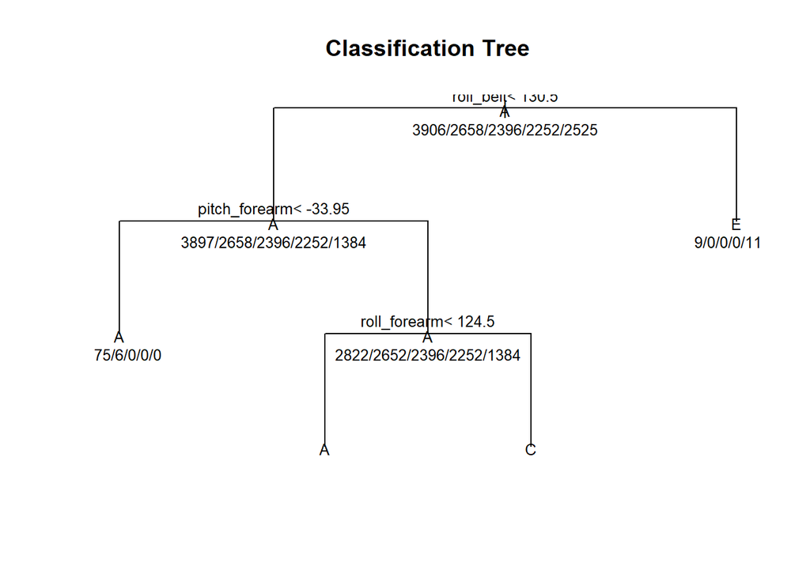

```r
## create the model
modelTree<-train(classe~.,method="rpart", data=trainClean)
## Plot the Tree
plot(modelTree$finalModel,uniform=TRUE,main="Classification Tree")
text(modelTree$finalModel,use.n=TRUE,all=TRUE,cex=0.8)
```

```r
##Create the prediction
predictTree<-predict(modelTree,testClean)
## Sumamry table
table(predictTree,testClean$classe)
```

```
##
## predictTree    A    B    C    D    E
##           A 1549  738  500  600  223
##           B    0    0    0    0    0
##           C  120  401  526  364  369
##           D    0    0    0    0    0
##           E    5    0    0    0  490
```

```r
##Calculate accuracy
accuracyTree<-sum(predictTree==testClean$classe)/length(testClean$classe)
```

One can see that the accuracy of 0.4358539 is pretty low and the model does not do a great job predicting the test dataset.

## Random Forests

Based on the disappointing results from the Random tree model, we now fit a random foorest model to the data.

```r
## create the model
modelForest<-randomForest(classe~., data=trainClean)
## Plot the Tree
## plot(modelTree$finalModel,uniform=TRUE,main="Classification Tree")
##Create the prediction
predictForest<-predict(modelForest,testClean)
## Sumamry table
table(predictForest,testClean$classe)
```

```
##
## predictForest    A    B    C    D    E
##             A 1673   10    0    0    0
##             B    1 1106    6    0    2
##             C    0   21 1013    7    3
##             D    0    2    7  956    4
##             E    0    0    0    1 1073
```

```r
##Calculate accuracy
accuracyForest<-sum(predictForest==testClean$classe)/length(testClean$classe)
```

One can see that the accuracy of 0.9891249 is much better in predicting the testing Dataset.

## Predicting the Final Test

We use the forest model from the previous sesction to now predict the test dataset. We also print out the results

```r
##Create the prediction
predictForestFINAL<-predict(modelForest,testclean_final)

predictForestFINAL
```

```
##  1  2  3  4  5  6  7  8  9 10 11 12 13 14 15 16 17 18 19 20
##  B  A  B  A  A  E  D  B  A  A  B  C  B  A  E  E  A  B  B  B
## Levels: A B C D E
```